# R Notebook

**Repeatability of a sexual signal trait**

This first data set was extracted from a paper by Griffith and Sheldon (2001, Animal Behaviour 61: 987–993), who measured the white forehead patch of 30 male collared flycatchers in two years on the Swedish island of Gotland. The patch is important in mate attraction, but varies in size from year to year. Our goal here will be to estimate the repeatability of patch length (mm). The data are here.

1. Read and examine the data. Create a plot showing the pair of measurements for each individual flycatcher in the two years of study. Is there evidence of measurement variability between years?

```r
library(lme4)
library(tidyverse)
library(bbmle)
flycatcher<-read.csv("~/GitHub/flycatcher.csv",stringsAsFactors = FALSE)
head(flycatcher)
```

|  | bird | patch | year |
| --- | --- | --- | --- |
| 1 | 1 | 10.5 | 1998 |
| 2 | 2 | 10.6 | 1998 |
| 3 | 3 | 8.7 | 1998 |
| 4 | 4 | 8.6 | 1998 |
| 5 | 5 | 9.0 | 1998 |
| 6 | 6 | 9.3 | 1998 |

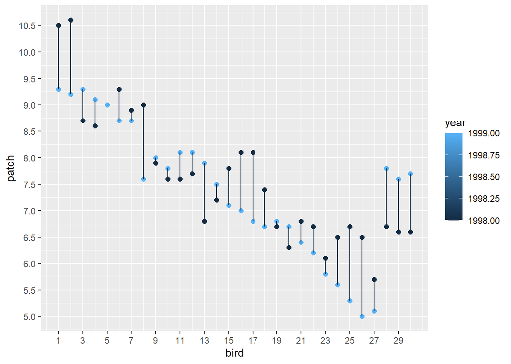

```r
library(ggplot2)
library(ggalt)
ggplot(flycatcher,aes(x=bird,y=patch,colour=year))+geom_point(size=2)+scale_x_continuous(breaks=seq(1, 30, by = 2))+scale_y_continuous(breaks=seq(5,10.6,by=.5))+geom_line(aes(group=bird))
```

```r
#Yes, there is variation in the patch measurement of each bird between the years.
```

*Fit a linear mixed-effects model*

2. Fit a linear mixed-effects model to the data, treating the individual birds as the random groups. Note: The two measurements on each bird were taken in successive years of the study. *For simplicity here, do not include year in the model.*

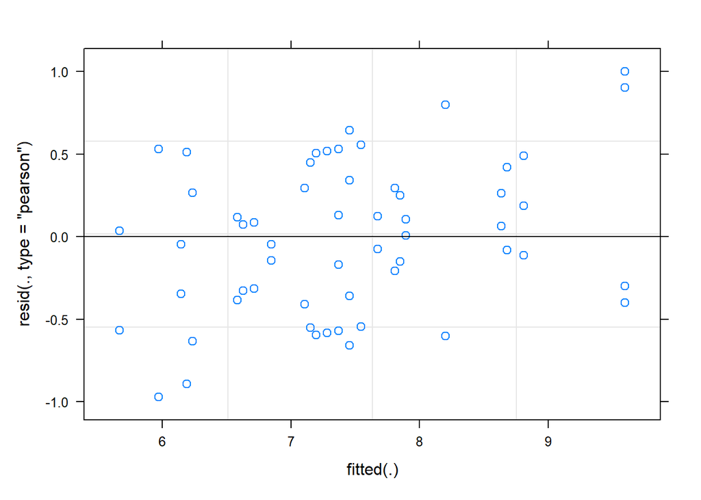

```r
m1 <- lmer(patch ~ 1 +(1|bird), data = flycatcher)
plot(m1)
```

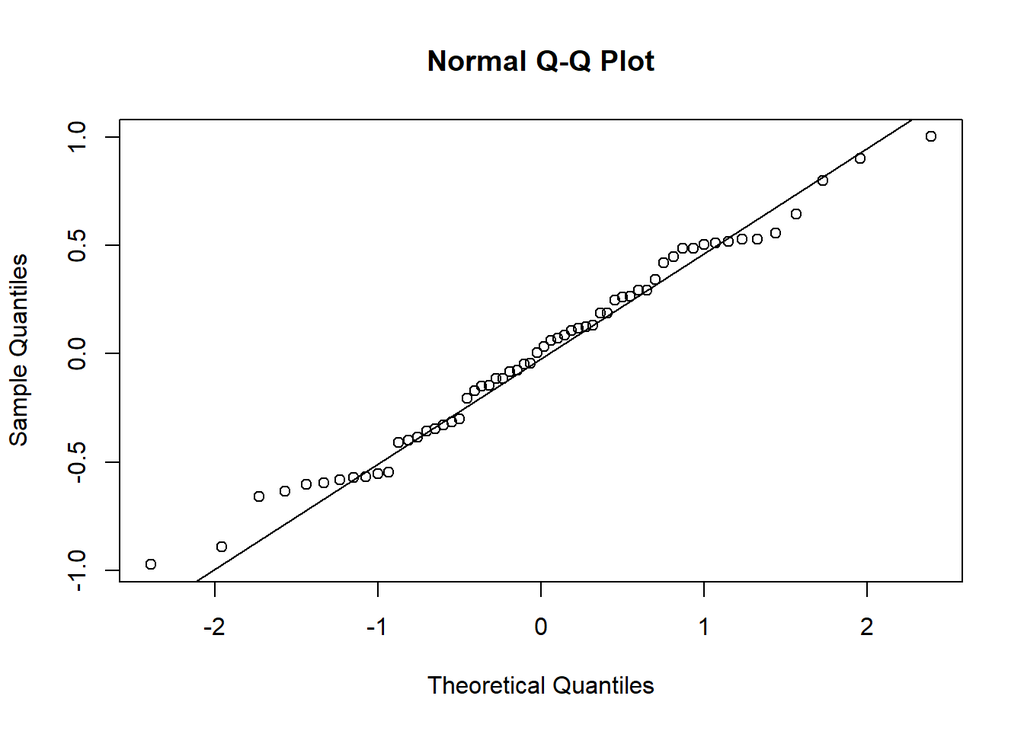

```r
qqnorm(resid(m1))
qqline(resid(m1))
```